# Treatwell Case Study

10/22/2019

## Task 1

The task is to analyse the data for shifts in behaviour or performance, to visualise these trends and suggest recommendations of the insights.

I was particularly interested in:

- Is there growth in bookings over time? If so, is it from new or repeating customers?
- How heavily are bookings dependent on paid channels?
- Are bookings by repeating customers mostly driven by discounts?

Ideally, bookings should be increasingly made by repeating, non-paid channels.

## How are bookings changing over time?

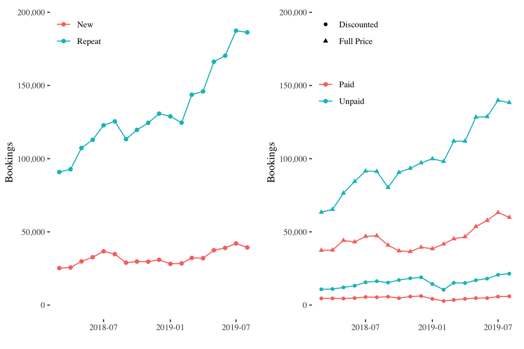

## What is fueling repeat bookings?

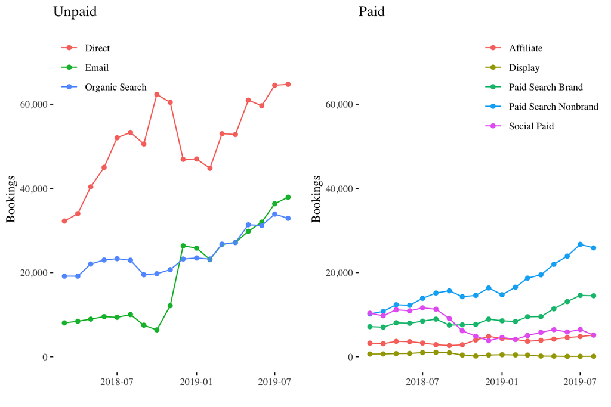

## Where are new bookings coming from?

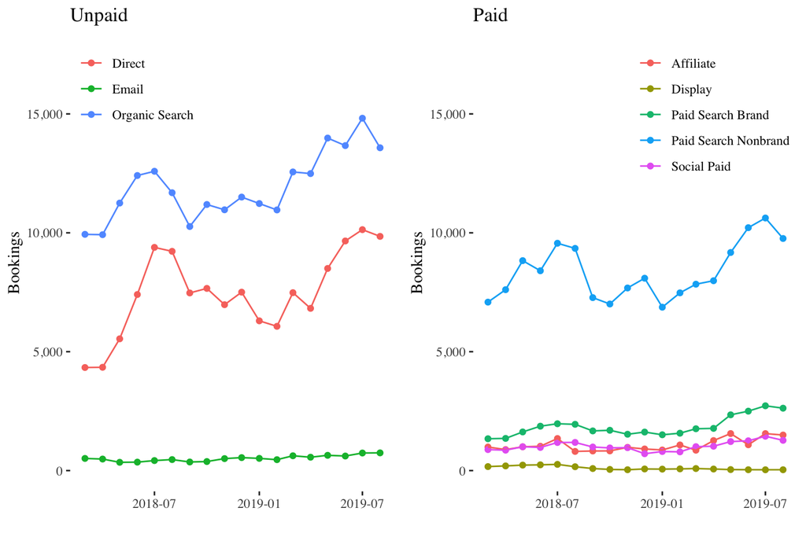

## What role does discounting play in unpaid bookings?

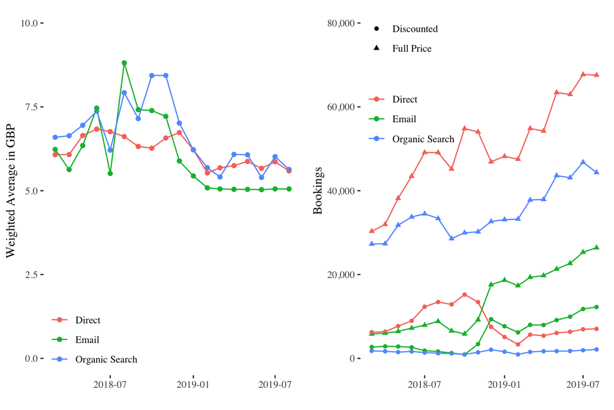

## Overall conclusions

- Monthly bookings have grown from 110k in 2018 to 225k in 2019, and increasingly from **repeat customers**.
- Repeating customers are **not being driven by heavy discounting** or **paid advertising**.
- New bookings are mostly unpaid.
- Within the paid bookings, search also dominates.
- Within the unpaid channel, **email has grown rapidly**.
- Within the paid channels, paid search non-brand bookings lead. There has been a noticable decrease in paid social bookings.

## Recommendations

- Paid social channel is underperforming compared to 2018 for repeat bookings. It is worth looking into why and whether it can be improved.
- The email channel has been a great source of growth for unpaid bookings. It seems like there was an effective discounting campaign there. Can it replicate across other channels?
- The U trend for direct bookings in both repeat and new costumers is worth investigating.

## Task 2

The task is to propose 2-3 pieces of analysis that could drive long term growth within paid channels.

I was particularly interested in:

- Using shifts in organic interest to inform paid channel strategy.
- Estimating customer lifetime value.
- Predicting the number of bookings a client will make using data from the first booking.

## Shifts in organic interest to inform paid channel strategy: Assumptions

There can be seasonal, cyclical or trend changes in the type of products that are booked which show shifts in consumer interest. The objective is to predict these trends and shift advertising strategy accordingly.

For instance, it is possible that people tend to book massages on weekdays when they are more stressed. Hence, advertising a massage towards the end of a workday would be more effective than on a Sunday morning.

## Shifts in organic interest to inform paid channel strategy: Methodology

The first step would be to take the booking type of all organic bookings and perform an exploratory data analysis to discover seasonal effects based on the time of the day, day of the week, month of the year, etc. Then one could add seasonal indicators to models predicting advertising efficiency to manage advertising budget and scheduling.

Assumptions:

- Non-paid bookings are an indication of "organic" consumer interest.

Data needed:

- Booking types for all orders.

## Shifts in organic interest to inform paid channel strategy: Examples

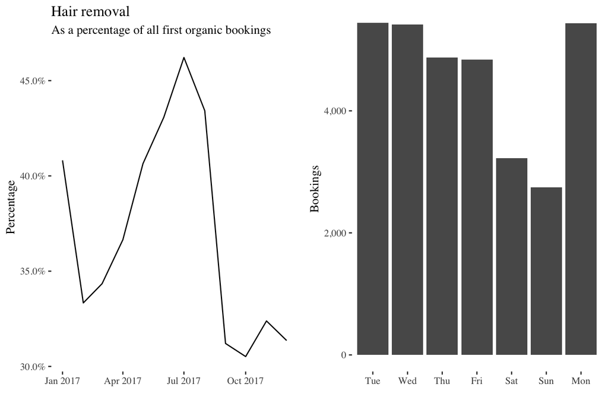

## Estimating Customer Lifetime Value: Rationale

Some clients are bigger spenders than others. The more a client spends, the more valuable he or she is.

Having a good estimate of how valuable a client will be also helps manage the costs of acquiring the client. It also gives an estimate for how long it will take for the investment in acquiring the client to be recouped.

Without an estimate for the CLV it is impossible to determine how much it is sensible to spend on a acquiring a client in a paid channel.

## Estimating Customer Lifetime Value: Methodology

The estimated customer lifetime value is a function of:

- the average purchase frequency rate
- the average purchase value
- the customers lifetime span

In order to calculate it we need to be able to estimate all three variables, for which we need the value of each order.

In addition, it makes sense to think about how to segment customers when calculating the CLV. A customer in Austria may be worth more than one in the UK.

## Predicting bookings: Rationale

In the data provided the top 25% of users make roughly 60% of bookings. Over half of the users book only once.

Lacking data for the value of the booking, a proxy for customer lifetime value might be the amount of bookings a customer makes over a year. The more engaged customers are, the happier they are with the platform, as well as the service providers.

If there is a way of predicting which clients book most treatments, then one can aim to acquire more such clients.

## Predicting bookings: Methodology

Picking a model based on observed values:

- observed values do not fit a Poisson distribution well due to overdispersion
- negative binomial is not an ideal fit either because over half of accounts booked only once
- transforming the data and modelling based on a **zero-inflated negative binomial model** seems to be the best fit

The **zero-inflated regression** (broadly) assumes two things:

- individuals either are prone to book again or are not,
- even if you are prone to book again, there is still a probability that you will not book

Another advantage is that these can be modelled seperately.

## Predicting bookings: Methodology

Given the data available, I added the following count model predictors:

- `first_booking_discounted`
- `first_booking_main_treatment`
- `first_booking_main_channel`
- `first_bookings_platform`

As well as the following zero inflation model coefficient:

-`first_booking_discounted`

My assumption was that customers chasing discounts were less likely to make multiple bookings.

## Predicting booking number: Model Diagnostics

The zero inflated regression performs better than the negative binomial and the poisson regression based on the AIC.

Standard residual diagnostics from GLM indicate model has systematic deviances from ideal fit. Moreover, a lot of outliers have significant influence.

A more in depth analysis would look into outliers to make sure they do not skew the result.

## Predicting booking number: Results

That the first booking was discounted was not a significant predictor of having more than one booking. This suggests that offering discounts does not attract low quality clients.

Moreover, the following were significant positive predictors of booking count with the largest effect sizes:

- First treatment: Hair removal (0.22)
- First treatment: Other (0.85)
- First marketing channel: Email (0.66)
- First marketing channel: Paid Search Brand (0.67)
- First marketing channel: Organic (0.45)

## Predicting booking number: Actionable Insights

This analysis suggests that when acquiring new customers it is **better to advertise for hair removal than hair treatment** as the former tend to make significantly more bookings. Moreover, is worth investigating **what products fit the "Other"category** as these also make siginifcantly more bookings.

Most **engaged customers come either through email, paid search brand advertising or organically**. This makes intuitive sense, as these are most likely the clients who are actively seeking out the platform. To the extent that these platforms can be further scaled in this market, it seems worth doing.